# OSHA_Descriptive_Stat_Toxic_Var

Ambar Mishra

4/1/2021

## Importing data

```r
cleaned_data <- read.csv("CA_prison_insp_viol_2010_op_fac_long.csv")
```

# Calculating Summary Statistics

I will calculate the averages of the toxic variables.

## Frequency of Violation Type

```r
violation_occurances <- table(cleaned_data$viol_type)
violation_occurances
```

```
##
##   O   R   S
## 595  13 189
```

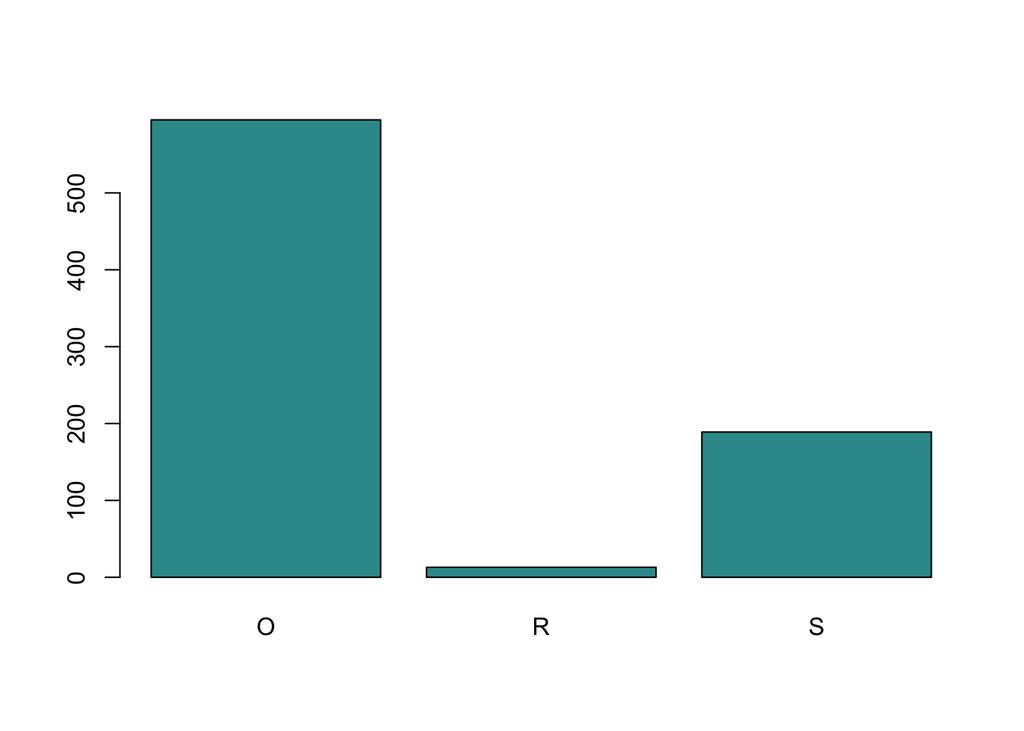

```r
barplot(violation_occurances, col = rgb(0.2, 0.6, 0.6))
```

Here is the interpretation of the output. O stands for other than serious (job safety). R is repeat violation and S is serious. W is willfully violated.

## Average of Nr_Instances

```r
number_instances <- cleaned_data$nr_instances
number_instances[is.na(number_instances)] = 0
# number_instances
```

Here is our mean:

```r
num_instances_mean = mean(number_instances, na.rm = TRUE)
num_instances_mean
```

```
## [1] 4.006404
```

```r
number_instances_median = median(number_instances, na.rm = TRUE)
number_instances_median
```

```
## [1] 1
```

```r
num_instances_max = max(number_instances, na.rm = TRUE)
num_instances_max
```

```
## [1] 1115
```

```r
num_instances_min = min(number_instances)
num_instances_min
```

```
## [1] 0
```

```r
library(formattable)
number_instances_frame <- data.frame(number_instances)
```

```r
num_inst_table <- table(number_instances)
num_inst_frame <- data.frame(num_inst_table)
```

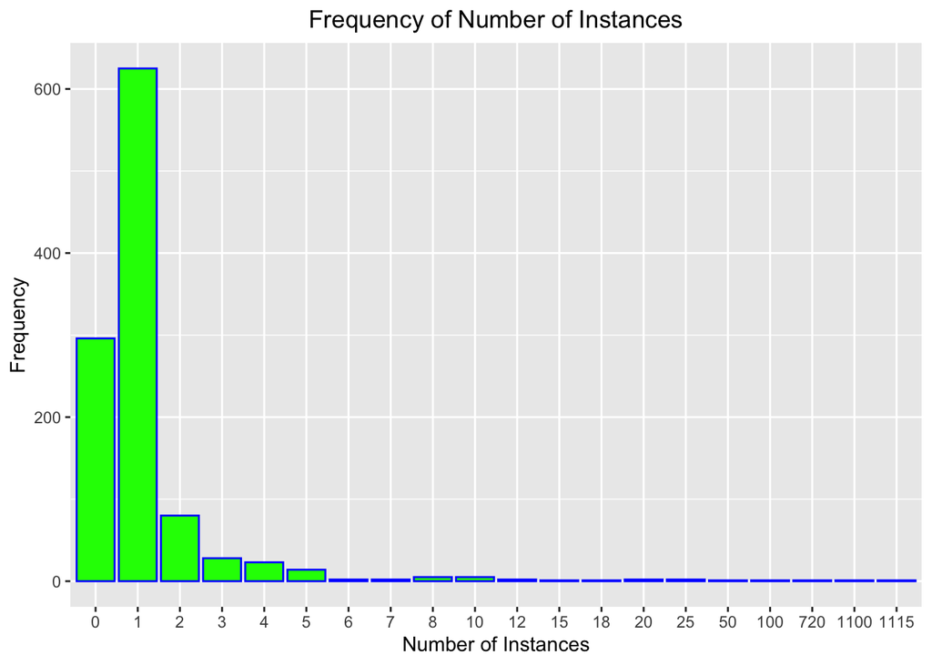

```r
library(ggplot2)
first_plot = ggplot(num_inst_frame, mapping = aes(x = number_instances, y = Freq)) + geom_bar(stat = 'identity', color = 'blue', fill = 'green') + ggtitle('Frequency of Number of Instances') + xlab("Number of Instances") + ylab("Frequency") + theme(plot.title = element_text(hjust = 0.5))
first_plot
```

As we can see, 1 is the most frequent amount of number of instances which is reported in our dataset which 625 frequencies throughout the entire dataset.

```r
table(cleaned_data$noviol, cleaned_data$nr_instances)
```

```
##
##           1   2   3   4   5   6   7   8  10  12  15  18  20  25  50 100 720
##   FALSE 625  80  28  23  14   2   2   5   5   2   1   1   2   2   1   1   1
##   TRUE    0   0   0   0   0   0   0   0   0   0   0   0   0   0   0   0   0
##
##         1100 1115
##   FALSE    1    1
##   TRUE     0    0
```

## Nr_Exposed

Note: I will replace the NA values with 0.

```r
number_exposed <- cleaned_data$nr_exposed
number_exposed[is.na(number_exposed)] = 0
# number_exposed
```

I will now find the descriptive statistics for the number of people exposed to hazardous substances.

```r
num_expose_mean <- mean(number_exposed)
```

```r
num_expose_max <- max(number_exposed)
```

Our highest amount of people exposed is 2,200 which is heavily alarming.

```r
num_expose_min = min(number_exposed)
num_expose_min
```

```
## [1] 0
```

```r
num_expose_med <- median(number_exposed)
num_expose_med
```

```
## [1] 2
```

```r
num_expose_table <- table(number_exposed)
num_expose_table
```

```
## number_exposed
##    0    1    2    3    4    5    6    7    8    9   10   12   13   14   15   16
##  383  145  105   53   57   41   30    8   31   10   26   10    3    6   20    2
##   17   18   20   25   26   30   35   38   40   45   49   50   60   62   63   64
##    1    3   20   15    7    1    3    3    5    1    2    6    7    1    2    4
##   67   70   71   73   76   80   90   96   99  100  110  140  150  161  247  250
##    1    7    2    1    1    2    4    1    2    5    2    3    2    1    1    1
##  300  342  400  402  500  600  650  700  800  912  913 1000 1100 1200 1309 1400
##    9    2    1    2    2    2    1    1    5    2    1    1    2    1    1    2
## 1800 1856 2000 2200
##    1    6    2    2
```

Here I will convert the table into a dataframe:

```r
num_expose_frame <- as.data.frame(num_expose_table)
View(num_expose_frame)
```

```r
library(formattable)
```

```r
formattable(num_expose_frame, align = 'l')
```

| number_exposed | Freq |
| --- | --- |
| 0 | 383 |
| 1 | 145 |
| 2 | 105 |
| 3 | 53 |
| 4 | 57 |
| 5 | 41 |
| 6 | 30 |
| 7 | 8 |
| 8 | 31 |
| 9 | 10 |
| 10 | 26 |
| 12 | 10 |
| 13 | 3 |
| 14 | 6 |
| 15 | 20 |
| 16 | 2 |
| 17 | 1 |
| 18 | 3 |
| 20 | 20 |
| 25 | 15 |
| 26 | 7 |
| 30 | 1 |
| 35 | 3 |
| 38 | 3 |
| 40 | 5 |
| 45 | 1 |
| 49 | 2 |
| 50 | 6 |
| 60 | 7 |
| 62 | 1 |
| 63 | 2 |
| 64 | 4 |
| 67 | 1 |
| 70 | 7 |
| 71 | 2 |
| 73 | 1 |
| 76 | 1 |
| 80 | 2 |
| 90 | 4 |
| 96 | 1 |
| 99 | 2 |
| 100 | 5 |
| 110 | 2 |
| 140 | 3 |
| 150 | 2 |
| 161 | 1 |
| 247 | 1 |
| 250 | 1 |
| 300 | 9 |
| 342 | 2 |
| 400 | 1 |
| 402 | 2 |
| 500 | 2 |
| 600 | 2 |
| 650 | 1 |
| 700 | 1 |
| 800 | 5 |
| 912 | 2 |
| 913 | 1 |
| 1000 | 1 |
| 1100 | 2 |
| 1200 | 1 |
| 1309 | 1 |
| 1400 | 2 |
| 1800 | 1 |
| 1856 | 6 |
| 2000 | 2 |
| 2200 | 2 |

```r
num_expose_first_nineteen = num_expose_frame[1:19, ]
num_expose_first_nineteen_frame = data.frame(num_expose_first_nineteen)
num_expose_first_nineteen_frame
```

```
##    number_exposed Freq
## 1               0  383
## 2               1  145
## 3               2  105
## 4               3   53
## 5               4   57
## 6               5   41
## 7               6   30
## 8               7    8
## 9               8   31
## 10              9   10
## 11             10   26
## 12             12   10
## 13             13    3
## 14             14    6
## 15             15   20
## 16             16    2
## 17             17    1
## 18             18    3
## 19             20   20
```

I had developed the number exposed ggplot to contain only until the amount of 20 people were exposed.

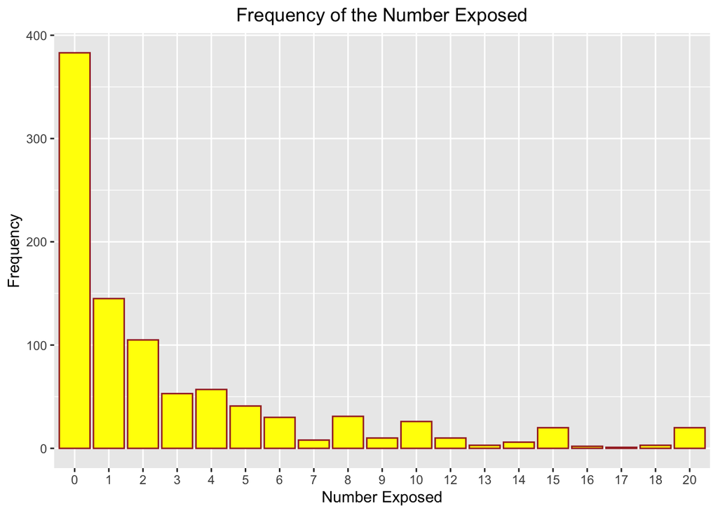

```r
library(ggplot2)
ggplot(num_expose_first_nineteen_frame, mapping = aes(x = number_exposed, y = Freq)) + geom_bar(stat = 'identity', color = 'brown', fill = 'yellow') + ggtitle('Frequency of the Number Exposed') + xlab("Number Exposed") + ylab("Frequency") + theme(plot.title = element_text(hjust = 0.5))
```

facet_wrap() or facet_grid()

how many were in inspection and not violation.

table number exposed and noviol. shows NA’s by inspection only. of these 0’s, 200 is cuz no violation. other is not reported.

## Gravity Column

1 is lowest and 10 is highest.

```r
gravity <- cleaned_data$gravity
gravity_frame <- data.frame(gravity)
```

Let me obtain some descriptive Statistics for the gravity column.

```r
# gravity_cleaned <- na.omit(cleaned_data$gravity)
# gravity_cleaned
```

```r
gravity_mean = mean(gravity)
gravity_mean
```

```
## [1] NA
```

```r
gravity_table <- table(gravity_frame)
gravity_frame_2 <- data.frame(gravity_table)
formattable(gravity_frame_2, align = 'l')
```

| gravity_frame | Freq |
| --- | --- |
| 1 | 91 |
| 3 | 14 |
| 5 | 143 |
| 10 | 110 |

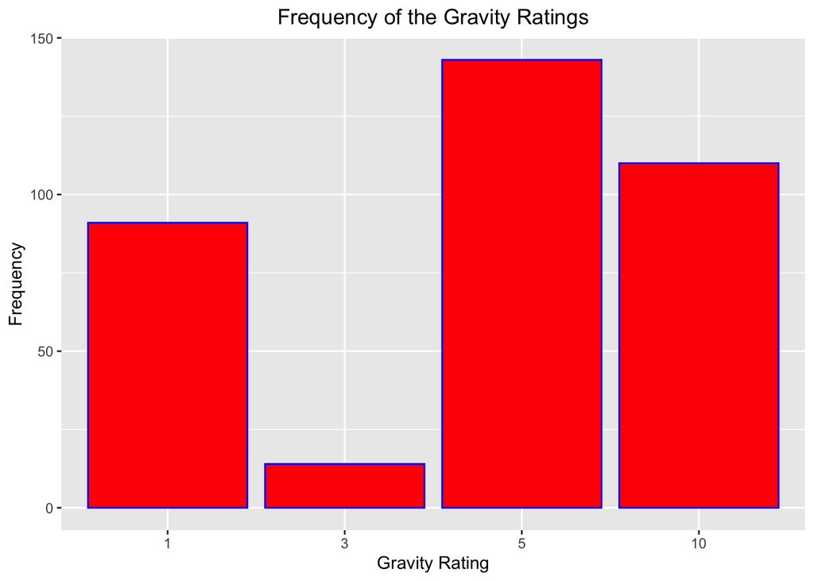

```r
gravity_plot <- ggplot(gravity_frame_2, aes(x=gravity_frame, y=Freq)) +geom_bar(stat = 'identity', color = 'blue', fill = 'red') + ggtitle('Frequency of the Gravity Ratings') + xlab("Gravity Rating") + ylab("Frequency") + theme(plot.title = element_text(hjust = 0.5))
gravity_plot
```

```r
# barplot(gravity_table)
```

High severity levels! Complain alot of bad things!

What do the NA’s represent?

Here is the amount of NA’s present in our dataset:

```r
sum(is.na(gravity))
```

```
## [1] 735
```

```r
sum(cleaned_data$noviol== TRUE)
```

```
## [1] 296
```

Which prisons had that violation and what violation associated with it. Haz_sub. helps for blog post. Identify those prisons and violation occured.

think ab what to highlight. Descriptive table. show mean, median or mode? choose which one.

## Descriptive Statistic Table

### Descriptive Statistic Tables Per Variables

#### Number of Exposed

I will use libraries to depict the number of exposed.

```r
library(knitr)
number_exposed_frame <- data.frame(num_expose_min, num_expose_med, num_expose_mean, num_expose_max)
```

Let me change the names of the columns and rows of my table.

```r
library(tidyverse)
# number_exposed_frame %>%
#   rename(
#      minimum = num_expose_min,
#      maximum = num_expose_max,
#      mean = num_expose_mean,
#      median = num_expose_med
#   )
```

```r
col_name <- paste(c("Minimum", "Median", "mean", "max"), sep = " ")
names(number_exposed_frame) <- col_name
row_names <- paste("Number Exposed")
rownames(number_exposed_frame) <- row_names
number_exposed_frame
```

```
##                Minimum Median     mean  max
## Number Exposed       0      2 49.05764 2200
```

```r
colnames(number_exposed_frame)
```

```
## [1] "Minimum" "Median"  "mean"    "max"
```

```r
library(knitr)
```

```r
formattable(number_exposed_frame, align = 'l')
```

|  | Minimum | Median | mean | max |
| --- | --- | --- | --- | --- |
| Number Exposed | 0 | 2 | 49.05764 | 2200 |

#### Number of Instances Table

```r
number_instances_frame_2 <- data.frame(num_instances_min, number_instances_median, num_instances_mean, num_instances_max)
```

```r
col_name <- paste(c("Minimum", "Median", "mean", "max"), sep = " ")
names(number_instances_frame_2) <- col_name
row_names <- paste("Number Instances")
rownames(number_instances_frame_2) <- row_names
number_instances_frame_2
```

```
##                  Minimum Median     mean  max
## Number Instances       0      1 4.006404 1115
```

```r
formattable(number_instances_frame_2, align = 'l')
```

|  | Minimum | Median | mean | max |
| --- | --- | --- | --- | --- |
| Number Instances | 0 | 1 | 4.006404 | 1115 |

#### Violation types

For the violation types, I can only focus on the amount of occurances for each type of violation.

```r
violation_frame <- data.frame(violation_occurances)
formattable(violation_frame, align = 'l')
```

| Var1 | Freq |
| --- | --- |
| O | 595 |
| R | 13 |
| S | 189 |

#### Combined Data Tables

```r
table_1 <- rbind(number_instances_frame_2,number_exposed_frame)
formattable(table_1, align ='l')
```

|  | Minimum | Median | mean | max |
| --- | --- | --- | --- | --- |
| Number Instances | 0 | 1 | 4.006404 | 1115 |
| Number Exposed | 0 | 2 | 49.057640 | 2200 |

### Intial Penalty

```r
initial_penalty_column <- cleaned_data$initial_penalty
initial_penalty_table <- table(initial_penalty_column)
initial_penalty_table
```

```
## initial_penalty_column
##       0     150     160     180     185     200     210     225     240     245
##     134      23       2       1      72       3       4      10       1       1
##     250     280     300     315     325     335     365     375     400     420
##       5      31      12       4       1       8       1      47       8      27
##     425     450     465     475     500     505     525     550     560     565
##       4      12       3       4       6       2       1       4      41       2
##     600     635     675     700     750     795     800     840     850     875
##      19      10       4      15      45       1      13       2       6       1
##     900     935    1000    1060    1125    1200    1350    1590    1875    2000
##       6      21      10       2      17       4       7       1       2       2
##    2250    2700 2925.55    3000    3375    3750    4000    4050    4500    5000
##       5       2       1       2      19       1       1       1       3      19
##    5060    5400    6075    6750    7200    7650    8435    9000   11250   13500
##       4       1       1      23       1       1       7       1       1       1
##   14400   16200   18000   20250   22500
##       3       1      18       3       4
```

Let me convert the intial penalty table into a data frame.

```r
initial_penalty_frame <- data.frame(initial_penalty_table)
initial_penalty_frame
```

```
##    initial_penalty_column Freq
## 1                       0  134
## 2                     150   23
## 3                     160    2
## 4                     180    1
## 5                     185   72
## 6                     200    3
## 7                     210    4
## 8                     225   10
## 9                     240    1
## 10                    245    1
## 11                    250    5
## 12                    280   31
## 13                    300   12
## 14                    315    4
```

[output cut: 61 more lines]

Ask about graphs! check quartiles and qunitiles. Showing that. Moderate, high end penalties. Check meaning of penalty.

Here is a graph of the first 20 penalties:

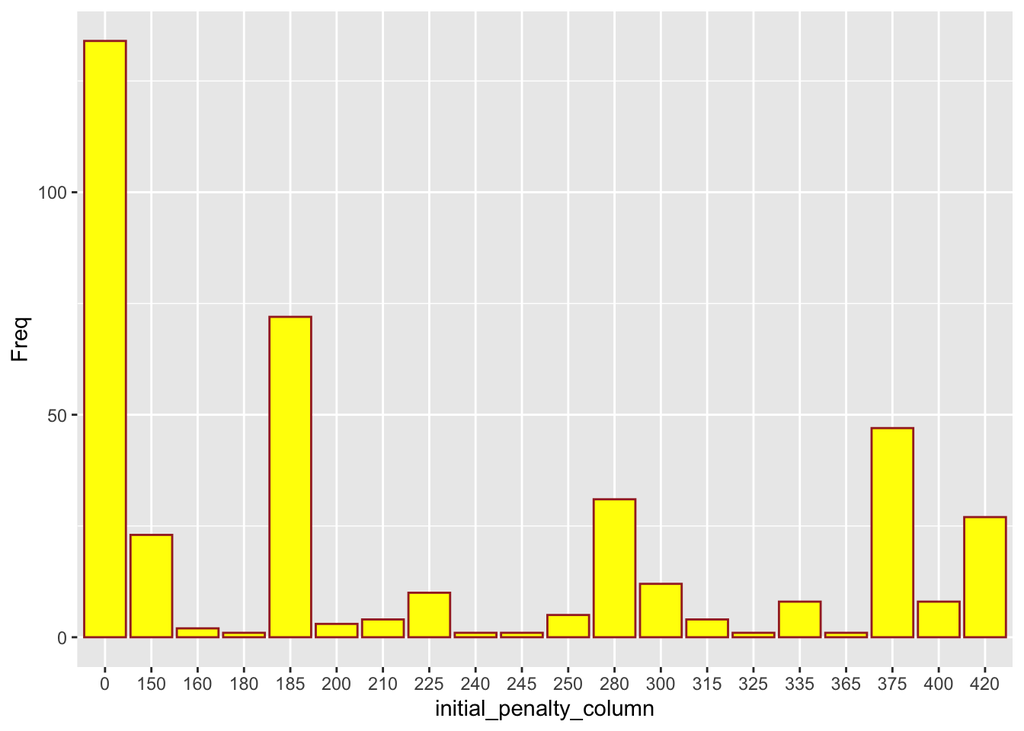

```r
a <- initial_penalty_table[1:20]
b = data.frame(a)
ggplot(b, mapping = aes(x = initial_penalty_column, y = Freq)) + geom_bar(stat = 'identity', color = 'brown', fill = 'yellow')
```

These are our top 20 penalties mentioned in the intial_penalty column.

Here is the graph of the next 20 penalities from 21 - 41:

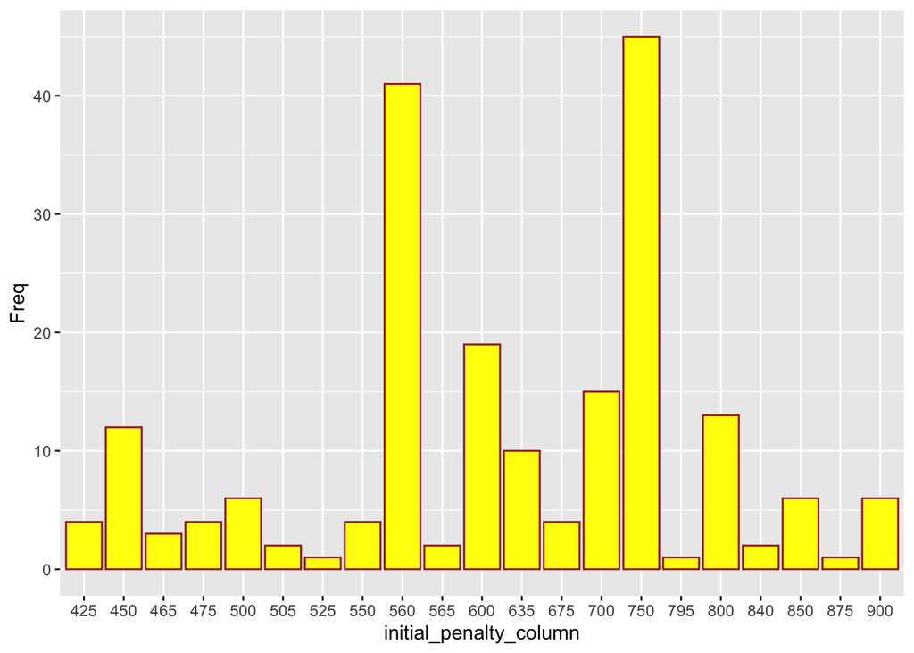

```r
a_2 <- initial_penalty_table[21:41]
b_2= data.frame(a_2)
ggplot(b_2, mapping = aes(x = initial_penalty_column, y = Freq)) + geom_bar(stat = 'identity', color = 'brown', fill = 'yellow')
```

Here is the graph of the 3rd batch of 20 penalties from 41-62:

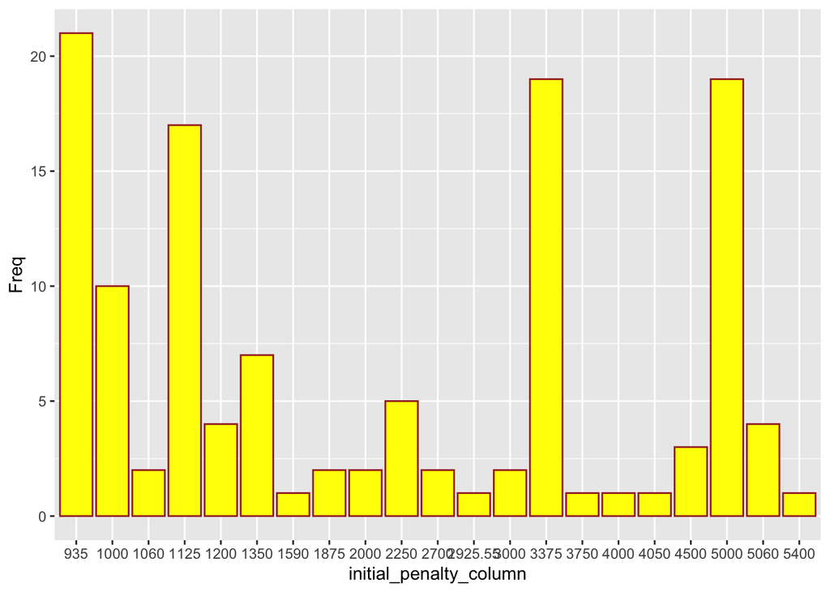

```r
a_3 <- initial_penalty_table[42:62]
b_3= data.frame(a_3)
ggplot(b_3, mapping = aes(x = initial_penalty_column, y = Freq)) + geom_bar(stat = 'identity', color = 'brown', fill = 'yellow')
```

Now, I will graph the last batch:

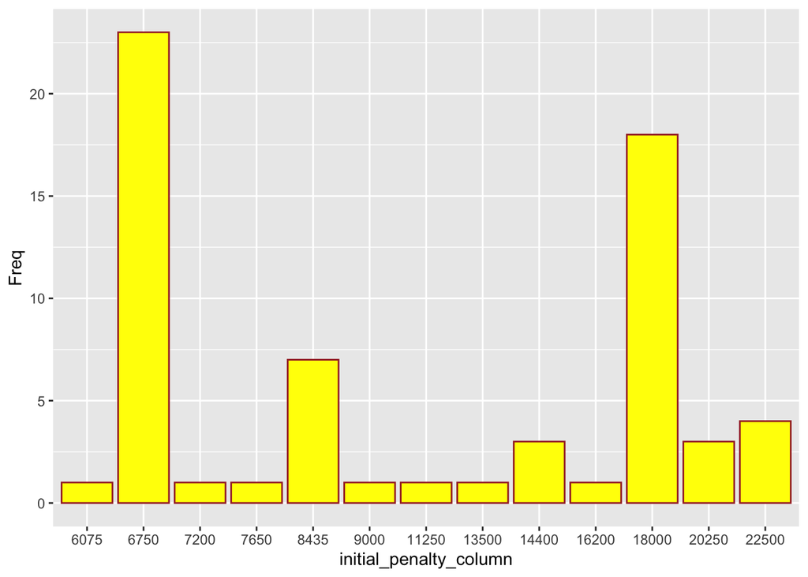

```r
a_4 <- initial_penalty_table[63:75]
b_4= data.frame(a_4)
ggplot(b_4, mapping = aes(x = initial_penalty_column, y = Freq)) + geom_bar(stat = 'identity', color = 'brown', fill = 'yellow')
```

All of these graphs have different distributions with the last batch showing a bimodial distribution.

Here is geom_pointrange:

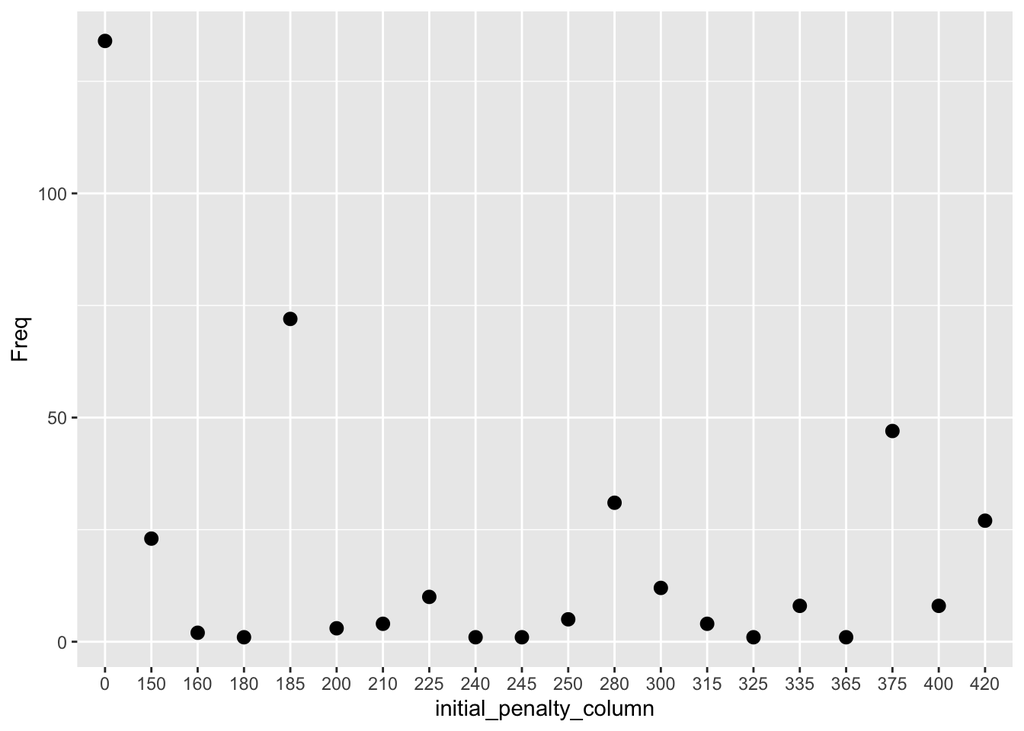

```r
ggplot(data = b) +
  geom_pointrange(mapping = aes(x = initial_penalty_column, y = Freq),
                  stat = "summary",
                  fun.min = function(z) {quantile(z,0.25)},
                  fun.max = function(z) {quantile(z,0.75)},
                  fun = median)
```

This graph is not showing any correlation releationships.

### Owner Type

There are clearly 4 different levels of owner types. I will form a table containing the occurances of these different owner types.

```r
owner_type_column = cleaned_data$owner_type
owner_type_column
```

[output not shown]

[output cut: 16 more lines]

```r
owner_type_table = table(owner_type_column)
owner_type_table
```

```
## owner_type_column
##   A   B   C   D
##  22 160 772 139
```

In this case, here are the meanings for the owner types.

Owner Types:

A = Private Company. B = Local Government C = State Government D = Federal Government

```r
owner_type_frame = data.frame(owner_type_table)
owner_type_frame
```

```
##   owner_type_column Freq
## 1                 A   22
## 2                 B  160
## 3                 C  772
## 4                 D  139
```

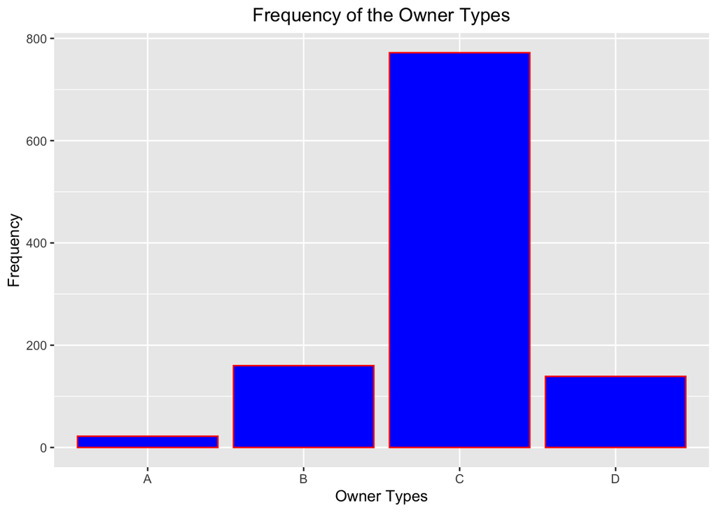

```r
owner_type_plot <- ggplot(owner_type_frame, aes(x=owner_type_column, y=Freq)) +geom_bar(stat = 'identity', color = 'red', fill = 'blue') + ggtitle('Frequency of the Owner Types') + xlab("Owner Types") + ylab("Frequency") + theme(plot.title = element_text(hjust = 0.5))
owner_type_plot
```

As we can see from this barplot, most of the owners who are listed in the violations dataset are from the state government. I believe this is a big concern that our state government is playing such a large role in the violations occuring at prisons. We can see that the next two highest institutions involved respectively are the local and federal governments. Private institutions are the lowest with only 22 cases. These results are surprising given that our governments are heavily involved in these violation cases.

Private vs. State? Either more inspection or violation.

### Union status column

PUT IN GITHUB.

```r
union_status_column = cleaned_data$union_status
union_status_column
```

[output not shown]

[output cut: 16 more lines]

```r
union_status_column[union_status_column == "A"] <- "N"
union_status_column[union_status_column == "B"] <- "Y"
union_status_column
```

[output not shown]

[output cut: 16 more lines]

We have replaced the A’s and B;s with the N’s and Y’s.

Let me drop the unused factor levels:

```r
union_status_column = droplevels(union_status_column)
union_status_column
```

[output not shown]

[output cut: 16 more lines]

```r
union_status_table = table(union_status_column)
union_status_table
```

```
## union_status_column
##   N   Y
## 442 651
```

We have seen that Y represents yes for union representation during inspection while N represents no union representation present during union inspection.

Here is a barplot to view the differences:

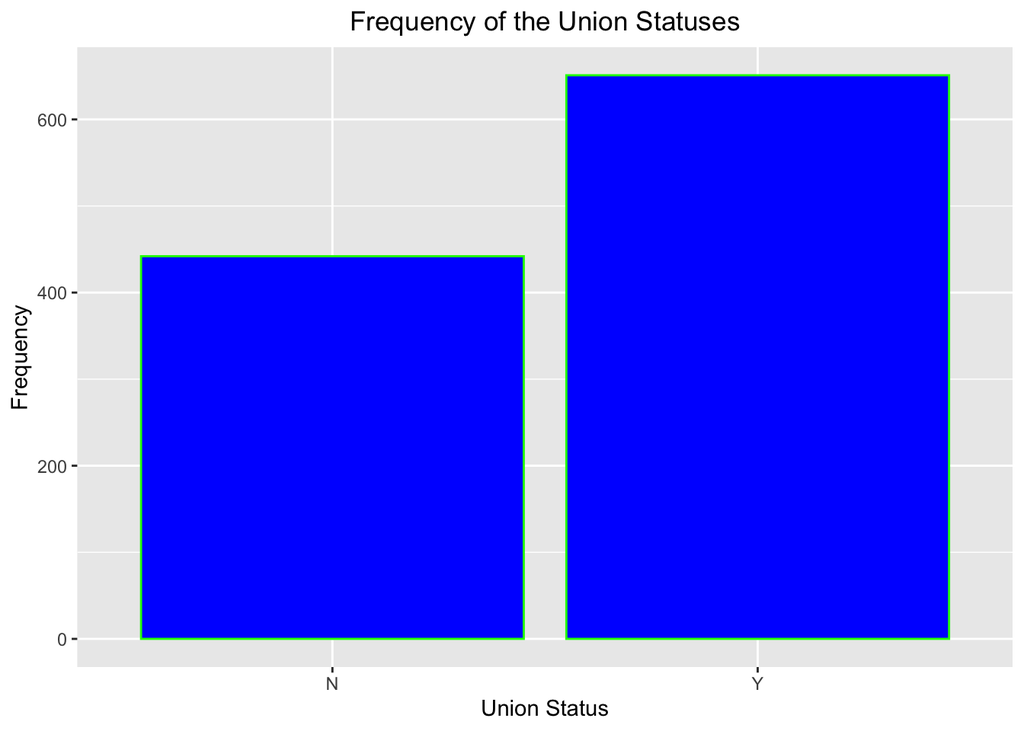

```r
library(ggplot2)
union_status_frame = data.frame(union_status_table)
union_status_plot <- ggplot(union_status_frame, aes(x=union_status_column, y=Freq)) +geom_bar(stat = 'identity', color = 'green', fill = 'blue') + ggtitle('Frequency of the Union Statuses') + xlab("Union Status") + ylab("Frequency") + theme(plot.title = element_text(hjust = 0.5))
union_status_plot
```

### Inspection Type

```r
insp_type_column = cleaned_data$insp_type
insp_type_column
```

[output not shown]

[output cut: 16 more lines]

Find a text table

Here are what the levels mean:

A = An accident type of inspection.

B = A complaint type of inspection.

C = A referral type of inspection.

F = A FollowUp type of inspection.

G = A Unprog. Rel type of inspection? (Combine G with J)

H = A planned type of inspection.

J = A unprog. other type of inspection?

M = this indicates either a fat/cat level. The “fat” level refers to an employee fatality while the “cat” level means employee catastrophe incident.

Here is our table for all of the possible factor levels present.

```r
insp_type_table = table(insp_type_column)
insp_type_table
```

```
## insp_type_column
##   A   B   C   F   G   H   J   M
## 250 661  15   6  33 113   2  13
```

Here is our visual representation of our different inspection types:

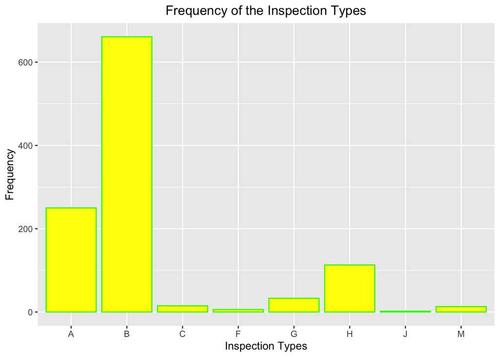

```r
# Maybe a legend
insp_type_frame = data.frame(insp_type_table)
insp_type_plot <- ggplot(insp_type_frame, aes(x=insp_type_column, y=Freq)) +geom_bar(stat = 'identity', color = 'green', fill = 'yellow') + ggtitle('Frequency of the Inspection Types') + xlab("Inspection Types") + ylab("Frequency") + theme(plot.title = element_text(hjust = 0.5))
insp_type_plot
```

Comparing activity numbers and seeing them on the OSHA search tool.

Discrepencies! See activity numbers and seeing it in the link to see if theres anything listed on website and not in data.

Check a systematic or random sample. Alot is missing -> Do a deep dive.

Add more onto the blog.